# Lectura y preparación de datos para Data Mining

# 5 Información sobre jugadores. Estadísticos descriptivos.

```r
Players <- select(nba,Player,Draft.Year,Height,Position,Weight) %>% distinct()
```

## 5.2 Listar el nombre de los 10 jugadores más bajos que han sido nombrados alguna vez jugadores de la semana. No debe repetirse ningún nombre.

```r
Top10shortplayers <- Players[order(Players$Height,decreasing = FALSE),]

Top10shortplayers[1:10,]
```

```
##                Player Draft.Year Height Position Weight
## 15      Isaiah Thomas       2011    175    Guard    185
## 264     Nate Robinson       2005    175    Guard    180
## 88      Michael Adams       1985    177    Guard    163
## 141   Terrell Brandon       1991    180    Guard    180
## 257         Ty Lawson       2009    180    Guard    195
## 91       Tim Hardaway       1989    182    Guard    175
## 122    Kenny Anderson       1991    182    Guard    168
## 134      Elliot Perry       1991    182    Guard    150
## 142     Allen Iverson       1996    182    Guard    165
## 152 Darrell Armstrong       1991    182    Guard    170
```

```r
rm(Top10shortplayers)
```

## 5.3 Listar el nombre de los 10 jugadores más altos que han sido nombrados y mostrar su altura. No debe repetirse ningún nombre.

```r
Top10tallplayers <- Players[order(Players$Height,decreasing = TRUE),]

Top10tallplayers[1:10,]
```

```
##                  Player Draft.Year Height Position Weight
## 192            Yao Ming       2002    228    Guard    310
## 128           Rik Smits       1988    223    Guard    250
## 37   Kristaps Porzingis       2015    221    Guard    240
## 136     Arvydas Sabonis       1985    220    Guard    279
## 190  Zydrunas Ilgauskas       1996    220    Guard    260
## 41  Kareem Abdul-Jabbar       1969    217    Guard    225
## 116     Dikembe Mutombo       1991    217    Guard    260
## 20           Marc Gasol       2007    216    Guard    255
## 89       David Robinson       1987    215    Guard    250
## 121    Shaquille O'Neal       1992    215    Guard    325
```

```r
rm(Top10tallplayers)
```

# 6 Eliminación de outliers.

## 6.1 Eliminar los outliers de la variable peso (Weight) y guardar en un data frame nba.avg

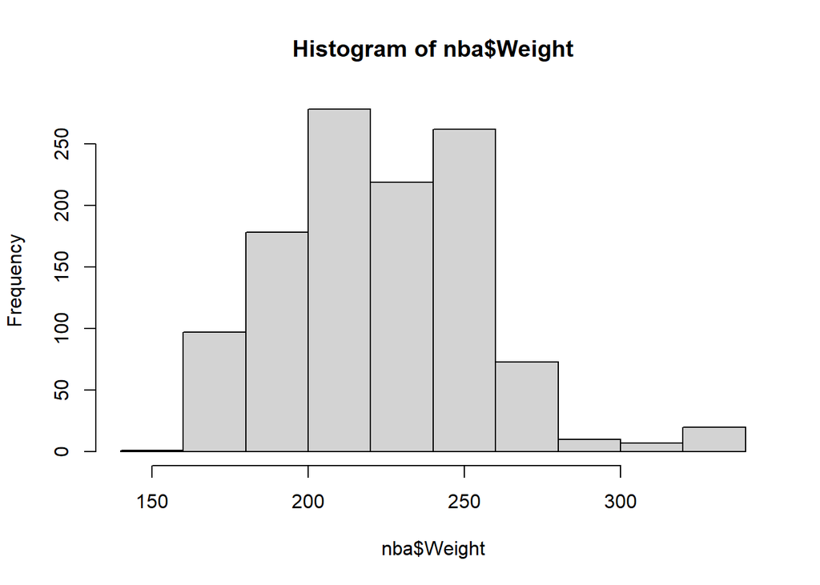

```r
## Mediante un histograma veo que los datos excepcionales son <150 y >272

hist(nba$Weight)
```

```r
table(nba$Weight)
```

```
##
## 150 163 165 168 170 174 175 178 180 183 184 185 186 187 188 189 190 191 193 194
##   1   2  24   1  15   3  20   8  24   1   5  37   3   1   1   9  30   7   6   5
## 195 196 198 199 200 205 207 208 209 210 211 212 215 217 218 220 221 222 223 224
##  19   5   3   2  44  31   1   3   6  59   5  33  48   1   1  90   2   4   1   1
## 225 228 229 230 231 232 233 235 240 242 244 245 246 247 249 250 251 252 253 254
##  22  20   7  15   4   1   4  36 102   1   3  48   2   1  14 106   9  11   4   5
## 255 259 260 261 264 265 266 268 270 279 280 285 289 307 310 325
##  26   1  31   2   1  45   6   5   4   4   6   3   7   1   6  20
```

```r
nba.avg = filter(nba,Weight>150 & Weight<272 ) %>% select(Weight)
nba.unique <-  select(nba,Weight)
```